# NBC ITS Analyses

Sam Dunn

24 September, 2018

This workthrough uses the mothur output file egenrated by following the mothur MiSeq SOP.

Load data from the mothur outptu file and load packages needed for data manipulation, analysis,and visulaization.

We are interested in the effects of time and substrate on the community we sequenced. Shannon Doversity is a good first metric. We need to select only 1 taxa level using the “taxlevel” column in our dataset and then perform the analysis.

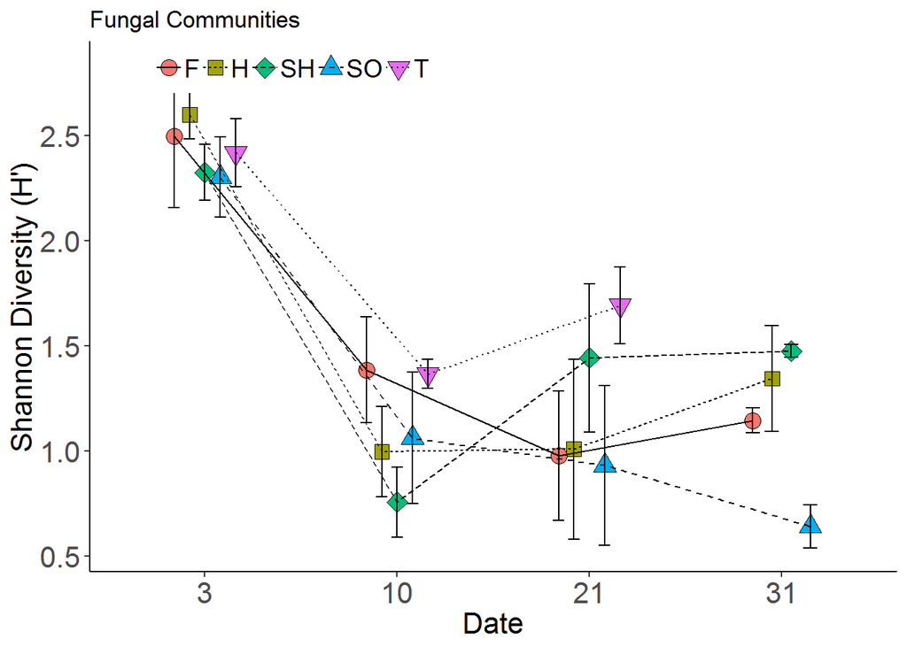

| statistic | p.value | method |
| --- | --- | --- |
| 0.9612678 | 0.07384013 | Shapiro-Wilk normality test |

| term | df | sumsq | meansq | statistic | p.value |
| --- | --- | --- | --- | --- | --- |
| Date | 3 | 17.459624 | 5.8198747 | 31.836565 | 3.133087e-10 |
| Substrate | 4 | 1.083536 | 0.2708839 | 1.481821 | 2.280761e-01 |
| Date:Substrate | 11 | 2.153206 | 0.1957460 | 1.070793 | 4.104042e-01 |
| Residuals | 36 | 6.580970 | 0.1828047 | NA | NA |

| term | comparison | estimate | conf.low | conf.high | adj.p.value |
| --- | --- | --- | --- | --- | --- |
| Date | 10-3 | -1.31306522 | -1.7385520 | -0.8875785 | 4.246381e-10 |
| Date | 21-3 | -1.21609853 | -1.6415853 | -0.7906118 | 3.793639e-09 |
| Date | 31-3 | -1.25633081 | -1.7320395 | -0.7806222 | 3.076655e-08 |
| Date | 21-10 | 0.09696670 | -0.3285200 | 0.5224534 | 9.299477e-01 |
| Date | 31-10 | 0.05673441 | -0.4189742 | 0.5324431 | 9.888697e-01 |
| Date | 31-21 | -0.04023228 | -0.5159409 | 0.4354764 | 9.959522e-01 |

We want to count the number of unqiue taxa we have ine ach sample (or OTUs, operational taxonomic units). TO do this we use a simple custom function and look for values greater than 0 in each row of the dataset

Absolute Abundance is only so useful. Here we calculate relatiev abundances for each taxa for its sample and plot stacked bars and a heatmap.

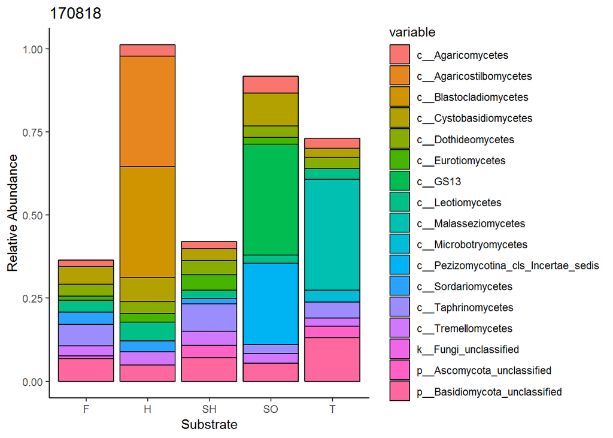

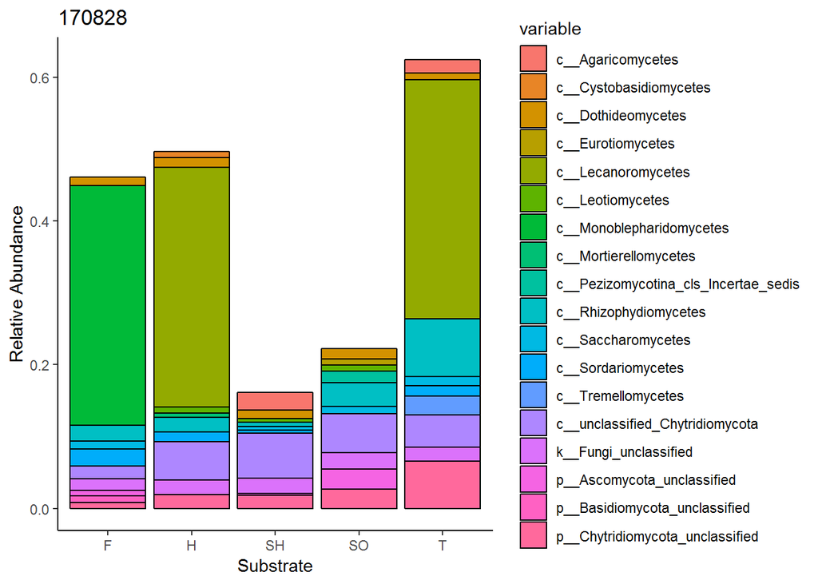

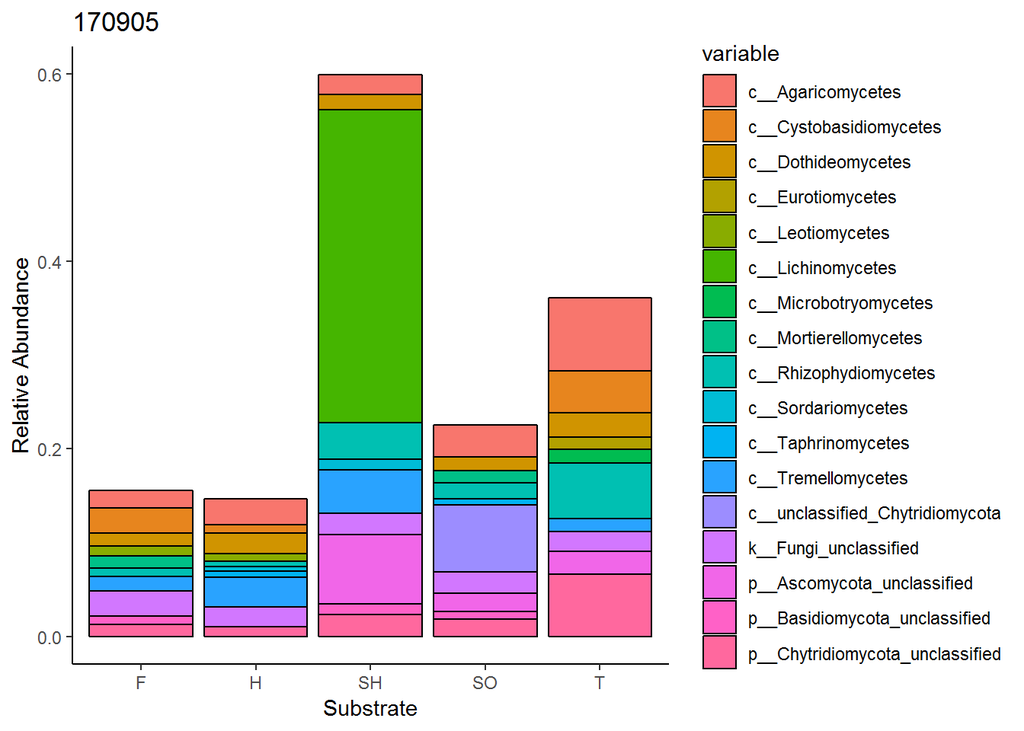

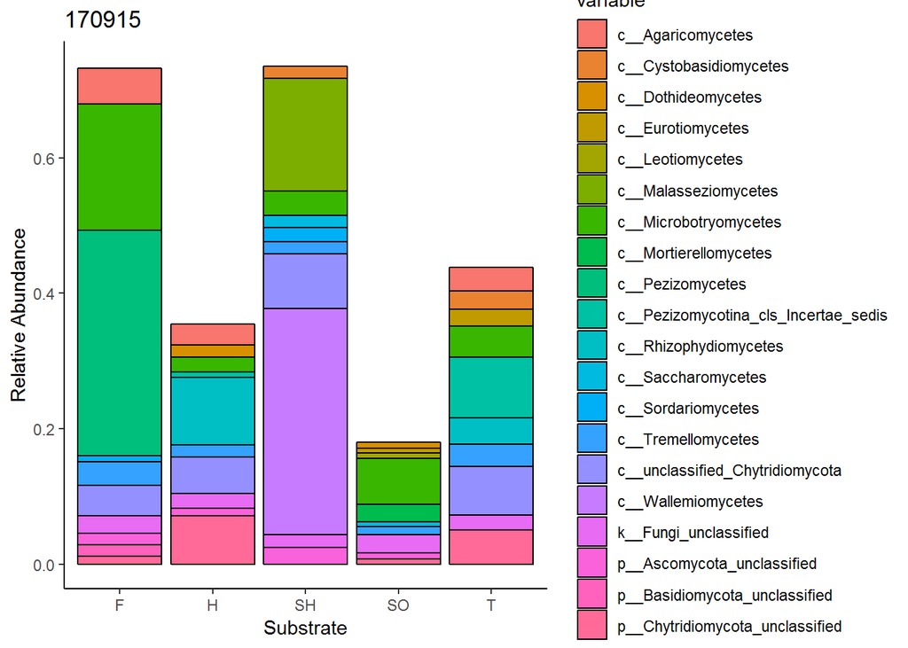

Stacked bars are not always the best for visualzing communities. I prefer heatmaps personally and figured out how to make a facetted heatmap. if you’re not familiar with facet_grid() in ggplot it will rock your world.

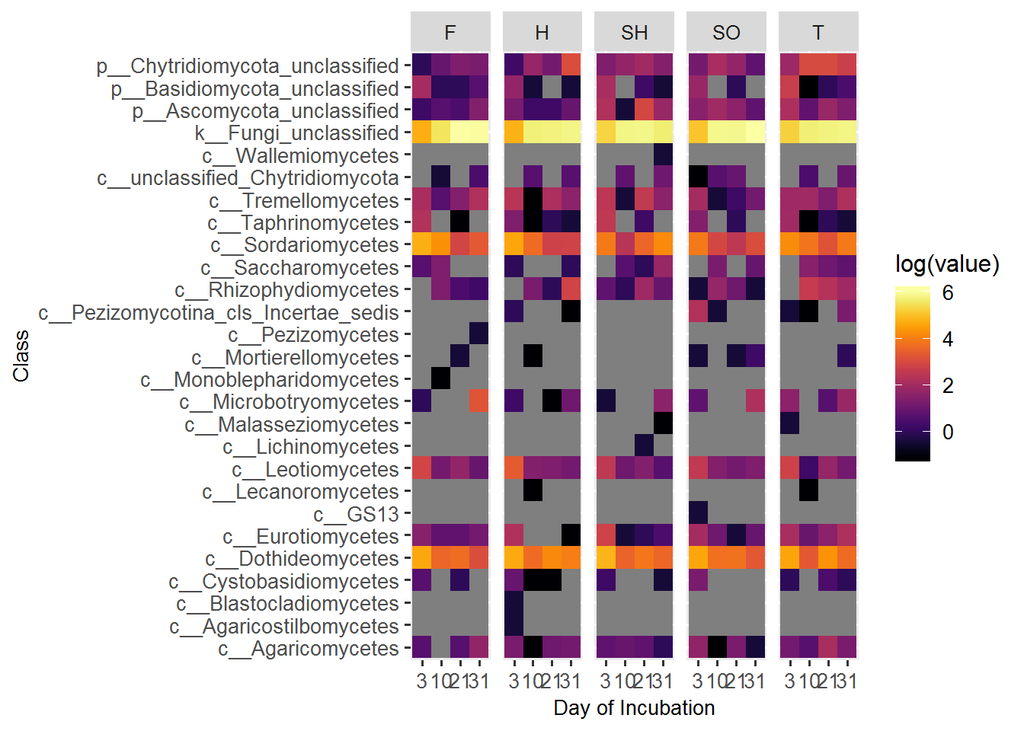

These are all pretty graphs so far, but you haven’t answered the question! Are there differences between substrates, dates, and their interaction?! Never fear we will answer that int he following code chunk using ANOSIM (analysis of similirity). ANOSIM is a multivairate method that is similar to ANOVA, but it instead uses a disimilarity matrix (bray curtis in oru case) instead of the data directly.

What’s better is that ANOSIM is fully compatible with NMDS plots (the following code chunk) So we can quantify differences between our treatment combinations and then plot them cleanly using NMDS!

```
##
## Call:
## adonis(formula = anosim.df ~ Substrate * Date, data = design.df)
##
## Permutation: free
## Number of permutations: 999
##
## Terms added sequentially (first to last)
##
##                Df SumsOfSqs MeanSqs F.Model      R2 Pr(>F)
## Substrate       5    1.1599 0.23197 11.2958 0.28617  0.001 ***
## Date            4    1.7169 0.42922 20.9008 0.42360  0.001 ***
## Substrate:Date 12    0.3549 0.02958  1.4402 0.08756  0.083 .
## Residuals      40    0.8215 0.02054         0.20267
## Total          61    4.0531                 1.00000
## ---
## Signif. codes:  0 '***' 0.001 '**' 0.01 '*' 0.05 '.' 0.1 ' ' 1
```

```
##
## Call:
## adonis(formula = anosim.3 ~ Substrate, data = design.3)
##
## Permutation: free
## Number of permutations: 999
##
## Terms added sequentially (first to last)
##
##           Df SumsOfSqs  MeanSqs F.Model      R2 Pr(>F)
## Substrate  4   0.42201 0.105502   1.173 0.31936  0.233
## Residuals 10   0.89941 0.089941         0.68064
## Total     14   1.32141                  1.00000
```

```
##
## Call:
## adonis(formula = anosim.10 ~ Substrate, data = design.10)
##
## Permutation: free
## Number of permutations: 999
##
## Terms added sequentially (first to last)
##
##           Df SumsOfSqs  MeanSqs F.Model      R2 Pr(>F)
## Substrate  4   0.17889 0.044721  1.7407 0.41047  0.064 .
## Residuals 10   0.25692 0.025692         0.58953
## Total     14   0.43581                  1.00000
## ---
## Signif. codes:  0 '***' 0.001 '**' 0.01 '*' 0.05 '.' 0.1 ' ' 1
```

```
##
## Call:
## adonis(formula = anosim.21 ~ Substrate, data = design.21)
##
## Permutation: free
## Number of permutations: 999
##
## Terms added sequentially (first to last)
##
##           Df SumsOfSqs  MeanSqs F.Model      R2 Pr(>F)
## Substrate  4   0.15074 0.037685 0.77315 0.23621  0.737
## Residuals 10   0.48742 0.048742         0.76379
## Total     14   0.63816                  1.00000
```

```
##
## Call:
## adonis(formula = anosim.31 ~ Substrate, data = design.31)
##
## Permutation: free
## Number of permutations: 999
##
## Terms added sequentially (first to last)
##
##           Df SumsOfSqs  MeanSqs F.Model      R2 Pr(>F)
## Substrate  4   0.23252 0.058130  2.2974 0.47888  0.004 **
## Residuals 10   0.25303 0.025303         0.52112
## Total     14   0.48555                  1.00000
## ---
## Signif. codes:  0 '***' 0.001 '**' 0.01 '*' 0.05 '.' 0.1 ' ' 1
```

[output not shown]

[output not shown]

[output not shown]

[output not shown]

[output not shown]

[output not shown]

[output not shown]

[output not shown]

[output not shown]

[output not shown]

[output not shown]

[output not shown]

[output not shown]

[output not shown]

[output not shown]

[output not shown]

[output not shown]

[output not shown]

[output not shown]

[output not shown]

| pairs | F.Model | R2 | p.value | p.adjusted | sig |
| --- | --- | --- | --- | --- | --- |
| F vs H | 2.565910 | 0.3907927 | 0.1 | 1 |  |
| F vs SH | 3.669319 | 0.4784413 | 0.1 | 1 |  |
| F vs SO | 1.034829 | 0.2055340 | 0.4 | 1 |  |
| F vs T | 5.042914 | 0.5576647 | 0.1 | 1 |  |
| H vs SH | 1.423574 | 0.2624790 | 0.4 | 1 |  |
| H vs SO | 1.674146 | 0.2950481 | 0.2 | 1 |  |
| H vs T | 1.314578 | 0.2473532 | 0.2 | 1 |  |
| SH vs SO | 2.561548 | 0.3903877 | 0.2 | 1 |  |
| SH vs T | 2.048486 | 0.3386775 | 0.4 | 1 |  |
| SO vs T | 3.165157 | 0.4417429 | 0.1 | 1 |  |

So we know whetehr our sample communities differ or not, but now we want to explain these differences (or lack thereof). How do we bring our non-community environmental data? We will use the envfit function in vegan to do this! Envfit takes your community distance matrices and looks for correlations with a similarlys tructured dataset. Your data sets (community and env) need to be the same size and not contain missing values for this to work.

```
## *** No convergence -- monoMDS stopping criteria:
##     19: stress ratio > sratmax
##      1: scale factor of the gradient < sfgrmin
```

```
##
## ***VECTORS
##
##                      NMDS1    NMDS2     r2 Pr(>r)
## NEP                0.51687 -0.85607 0.0173  0.678
## GPP                0.65311 -0.75726 0.1568  0.027 *
## Respiration       -0.99309 -0.11738 0.0708  0.177
## BG-ase             0.92650 -0.37628 0.3106  0.001 ***
## NAG-ase            0.80777 -0.58949 0.2121  0.006 **
## P-ase              0.97335 -0.22932 0.4928  0.001 ***
## Chl.a              0.77646  0.63017 0.1276  0.039 *
## Biomass            0.70963 -0.70457 0.1086  0.059 .
## Day of Incubation  0.99995 -0.01039 0.6249  0.001 ***
## SRP                0.99281 -0.11973 0.0755  0.152
## NO3                0.93820 -0.34611 0.3145  0.002 **
## NH4               -0.94095 -0.33853 0.4082  0.001 ***
## ---
## Signif. codes:  0 '***' 0.001 '**' 0.01 '*' 0.05 '.' 0.1 ' ' 1
## Permutation: free
## Number of permutations: 999
##
## ***FACTORS:
##
## Centroids:
##                         NMDS1   NMDS2
## Date_Sampled8/18/2017 -0.2911  0.0123
## Date_Sampled8/29/2017  0.0464 -0.0466
## Date_Sampled9/15/2017  0.1217 -0.0041
## Date_Sampled9/5/2017   0.1049  0.0429
## SubstrateF             0.0129  0.0283
## SubstrateH            -0.0147 -0.0383
## SubstrateSh           -0.0236  0.0038
## SubstrateSo           -0.0567  0.0259
## SubstrateT            -0.0281 -0.0263
##
## Goodness of fit:
##                  r2 Pr(>r)
## Date_Sampled 0.6461  0.001 ***
## Substrate    0.0250  0.943
## ---
## Signif. codes:  0 '***' 0.001 '**' 0.01 '*' 0.05 '.' 0.1 ' ' 1
## Permutation: free
## Number of permutations: 999
##
## 10 observations deleted due to missingness
```

|  | NMDS1 | NMDS2 | Assay | pvals |
| --- | --- | --- | --- | --- |
| GPP | 0.2586321 | -0.299874978 | GPP | 0.027 |
| BG-ase | 0.5163680 | -0.209714137 | BG-ase | 0.001 |
| NAG-ase | 0.3720208 | -0.271492710 | NAG-ase | 0.006 |
| P-ase | 0.6832987 | -0.160980880 | P-ase | 0.001 |
| Chl.a | 0.2773096 | 0.225064448 | Chl.a | 0.039 |
| Day of Incubation | 0.7904629 | -0.008215985 | Day of Incubation | 0.001 |
| NO3 | 0.5261601 | -0.194103929 | NO3 | 0.002 |
| NH4 | -0.6012080 | -0.216300107 | NH4 | 0.001 |

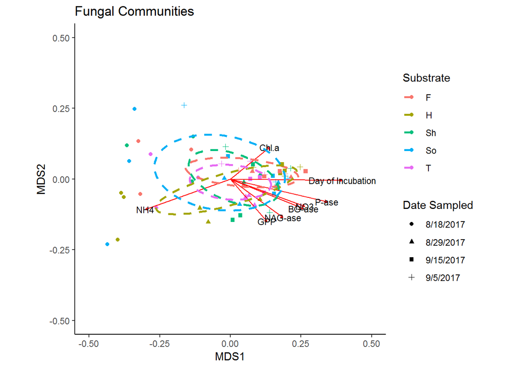

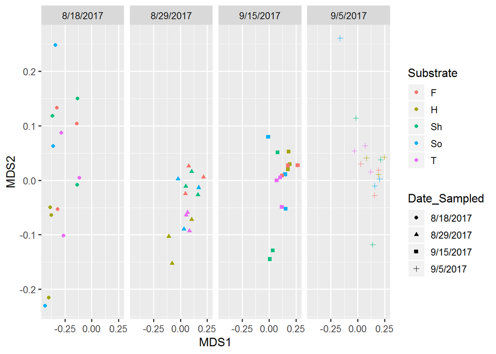

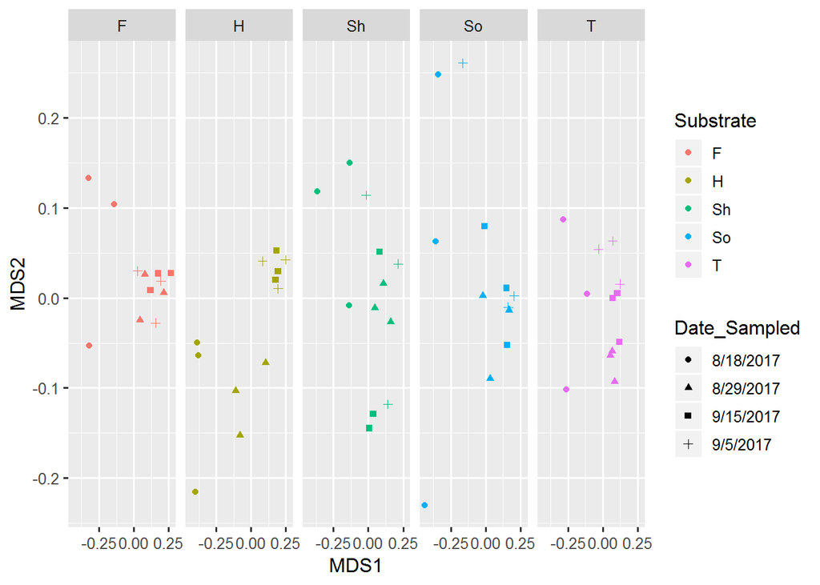

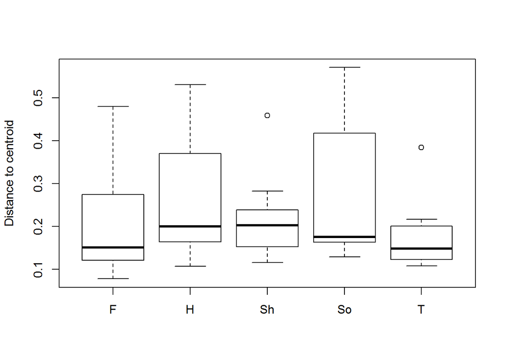

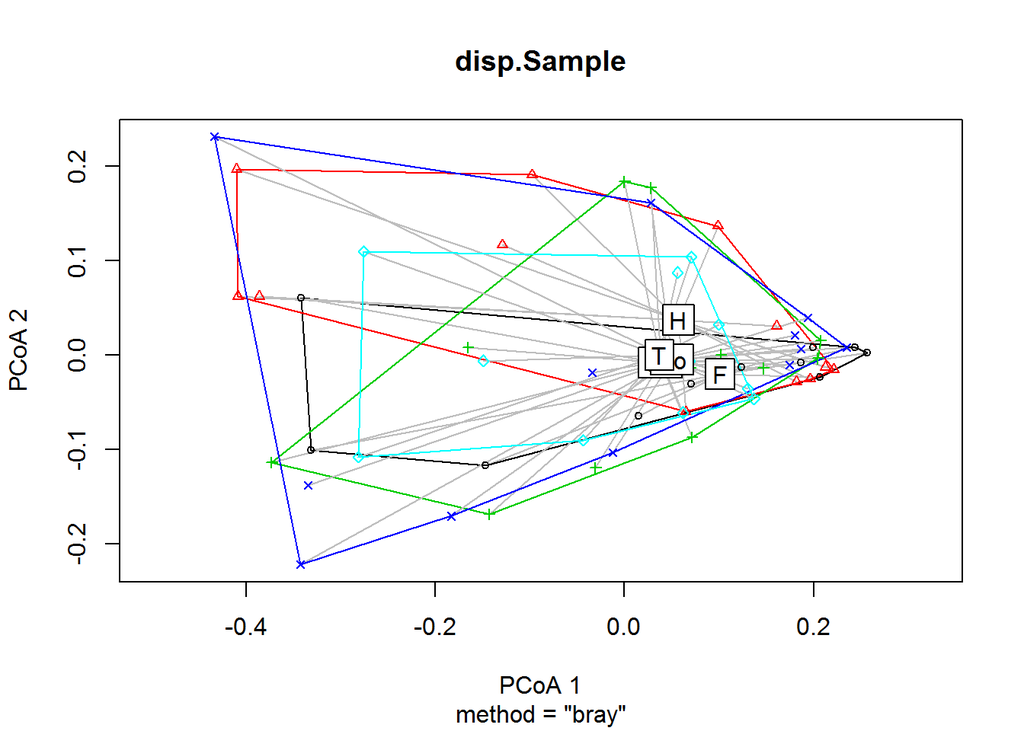

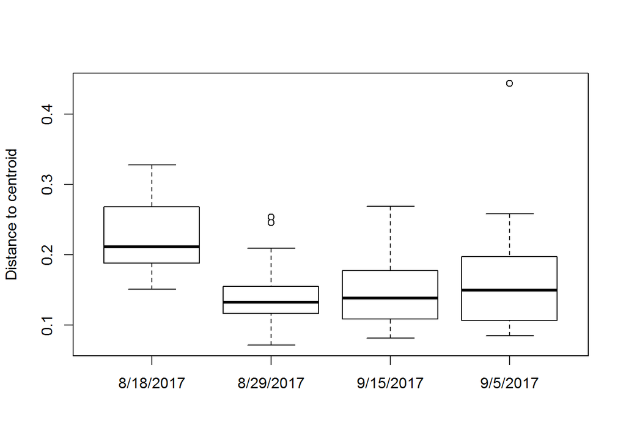

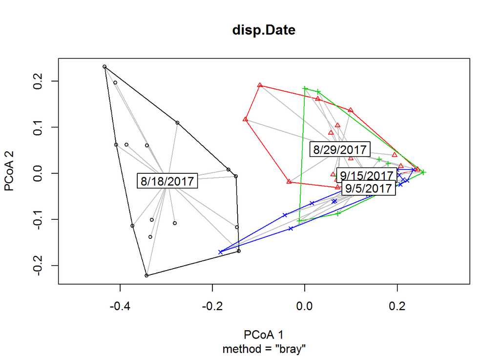

```
##   Tukey multiple comparisons of means
##     95% family-wise confidence level
##
## Fit: aov(formula = distances ~ group, data = df)
##
## $group
##               diff         lwr        upr     p adj
## H-F    0.051827965 -0.09778219 0.20143812 0.8644040
## Sh-F   0.003933658 -0.14567650 0.15354382 0.9999929
## So-F   0.054986738 -0.09462342 0.20459690 0.8372797
## T-F   -0.026587719 -0.17619788 0.12302244 0.9869133
## Sh-H  -0.047894307 -0.19750447 0.10171585 0.8945864
## So-H   0.003158773 -0.14645139 0.15276893 0.9999971
## T-H   -0.078415684 -0.22802584 0.07119447 0.5807240
## So-Sh  0.051053080 -0.09855708 0.20066324 0.8706725
## T-Sh  -0.030521378 -0.18013154 0.11908878 0.9781397
## T-So  -0.081574458 -0.23118462 0.06803570 0.5429422
```

```
##   Tukey multiple comparisons of means
##     95% family-wise confidence level
##
## Fit: aov(formula = distances ~ group, data = df)
##
## $group
##                             diff         lwr          upr     p adj
## 8/29/2017-8/18/2017 -0.081177051 -0.14641452 -0.015939586 0.0090239
## 9/15/2017-8/18/2017 -0.076374595 -0.14161206 -0.011137130 0.0155716
## 9/5/2017-8/18/2017  -0.058449593 -0.12368706  0.006787872 0.0943231
## 9/15/2017-8/29/2017  0.004802456 -0.06043501  0.070039921 0.9973445
## 9/5/2017-8/29/2017   0.022727458 -0.04251001  0.087964923 0.7929577
## 9/5/2017-9/15/2017   0.017925003 -0.04731246  0.083162468 0.8856556
```

```
##
##  Homogeneity of multivariate dispersions
##
## Call: betadisper(d = its.ord.dist, group = its.ORD$Substrate)
##
## No. of Positive Eigenvalues: 34
## No. of Negative Eigenvalues: 25
##
## Average distance to median:
##      F      H     Sh     So      T
## 0.2116 0.2634 0.2156 0.2666 0.1850
##
## Eigenvalues for PCoA axes:
##  PCoA1  PCoA2  PCoA3  PCoA4  PCoA5  PCoA6  PCoA7  PCoA8
## 2.4437 0.5315 0.3145 0.1902 0.1313 0.1180 0.1035 0.0889
```

```
##
##  Homogeneity of multivariate dispersions
##
## Call: betadisper(d = its.ord.dist, group = its.ORD$Date_Sampled)
##
## No. of Positive Eigenvalues: 34
## No. of Negative Eigenvalues: 25
##
## Average distance to median:
## 8/18/2017 8/29/2017 9/15/2017  9/5/2017
##    0.2272    0.1460    0.1508    0.1687
##
## Eigenvalues for PCoA axes:
##  PCoA1  PCoA2  PCoA3  PCoA4  PCoA5  PCoA6  PCoA7  PCoA8
## 2.4437 0.5315 0.3145 0.1902 0.1313 0.1180 0.1035 0.0889
```

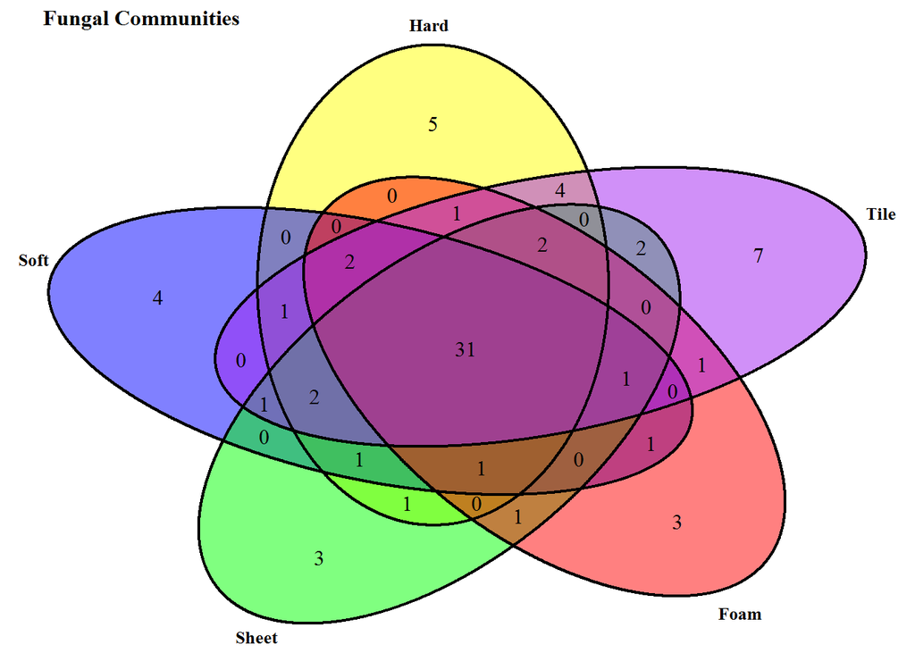

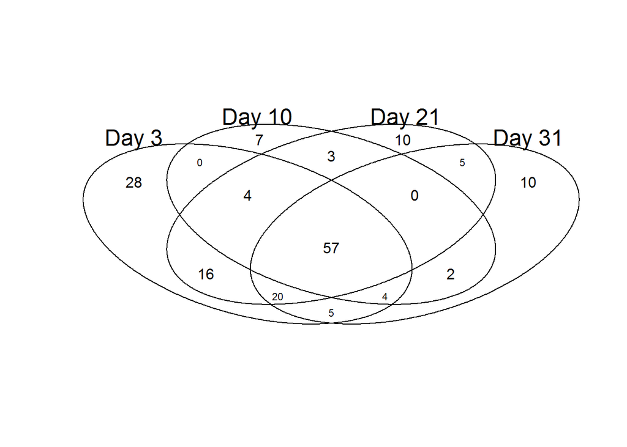